# BMS Bootcamp Coding Workshop

Emily Jones

8 September 2016

**Goal: Given an espression analysis in a paper, find the data and import it into R, find the method used for analysis and how to execute it in R, and recreate the figure.**

### Find some data

Open [“Transcriptome Profile of Human Colorectal Adenomas.”](http://mcr.aacrjournals.org/content/5/12/1263.long) Go to figure 1A. What is the main point of this figure? How can you improve it?

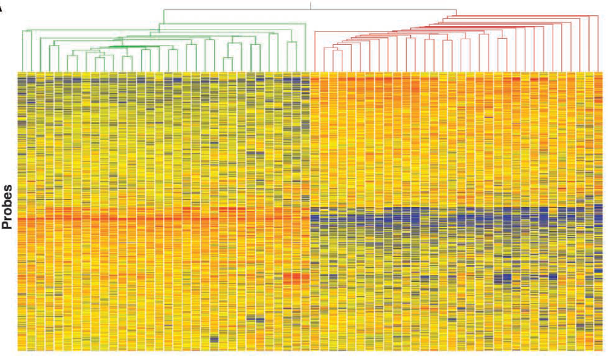

Figure 1A

On the next page, find highlighted in the caption a description of how this figure was created.

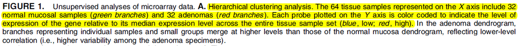

Figure 1A caption

We are going to recreate this figure from scratch; but first, we’ll need some information.

### Import your data

The authors of this paper have kindly published their raw data. Open the [NCBI GEO DataSet Browser](http://www.ncbi.nlm.nih.gov/sites/GDSbrowser/). Search for the paper title to find the dataset. Locate the DataSet Record at the top of the page.

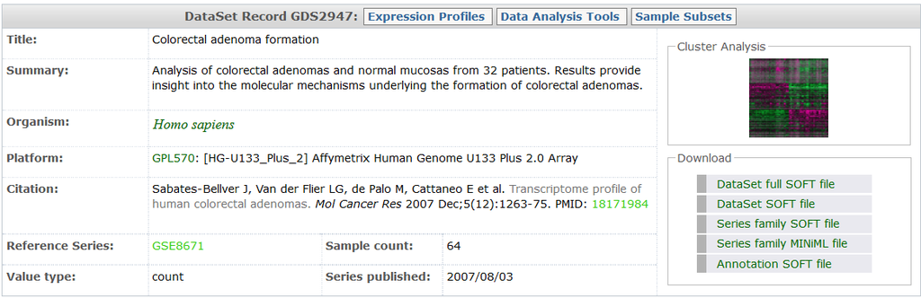

GDS Record

You’ll notice at the side of the page there is a “Download” section. That’s promising, but the file formats are unfamiliar. What exactly is “SOFT” file, and how do we read it? Luckily, R will allow us to skip downloading or figuring out file formats all together. To see how we can parse a SOFT file in R, Google something like “open GEO SOFT files in R.” One of the first few links is [a post written by a student at the University of Warwick](http://www2.warwick.ac.uk/fac/sci/moac/people/students/peter_cock/r/geo/), with a great explanation about what a GDS means and how to read it into R.

Install GEOquery by starting Bioconductor and using the `biocLite()` command. Load the package with `library()` and use it to parse the GEO SOFT file into an R object.

```r
#pull and parse the GEO SOFT file
source("http://bioconductor.org/biocLite.R") #start bioconductor
biocLite()
biocLite("GEOquery") #install package that parses GEO SOFT files
library(Biobase) #load packages
library(GEOquery)
cancer <- getGEO('GDS2947') #pull the SOFT file from GEO (may cause firewall alert)
```

### Explore and clean your data

Explore this data set with `str()`. It looks like it’s samples from 32 patients, which each gave normal mucosa and adenoma samples. Each sample has results for 55,000 tests; what are these tests for? Can you find the same information using `Meta()`?

```r
str(cancer) #not shown on this page
```

```r
Meta(cancer)$sample_type #check out individual parts of the metadata
```

```
## [1] "RNA"
```

```r
Meta(cancer)$sample_count
```

```
## [1] "64"
```

```r
Meta(cancer)$description[1]
```

```
## [1] "Analysis of colorectal adenomas and normal mucosas from 32 patients. Results provide insight into the molecular mechanisms underlying the formation of colorectal adenomas."
```

Look at a subset the raw data using `Table()` and accessing rows 1-10 and columns 1-10 using `[1:10,1:10]`.

```r
  Table(cancer)[1:10,1:10]
```

```
##       ID_REF IDENTIFIER GSM215051 GSM215052 GSM215053 GSM215054  GSM215055
## 1  1007_s_at    MIR4640 4899.9400 4743.3600 4234.3600 3674.4100 4354.63000
## 2    1053_at       RFC2  475.4580  587.8790  523.4000  445.6070  384.78900
## 3     117_at      HSPA6   35.0663   70.2514   86.9224  104.1820   96.70090
## 4     121_at       PAX8 1127.1700  716.0000  725.7930  834.6400  884.97600
## 5  1255_g_at     GUCA1A   23.2336   60.6288   92.5525  101.9570    9.14719
## 6    1294_at    MIR5193  680.2760  554.4730  675.3190  708.2540  617.98600
## 7    1316_at       THRA  236.5610  188.3120   96.1972  144.2530   92.01650
## 8    1320_at     PTPN21  186.0310  108.3890  194.4290   93.4663  151.09400
## 9  1405_i_at       CCL5 1013.0200 2017.7600 1489.6100  735.2600 1638.87000
## 10   1431_at     CYP2E1  111.0870   29.6851   34.1966   86.7639   42.67320
##    GSM215056 GSM215057 GSM215058
## 1  3529.9500 4543.8000 4581.3900
## 2   501.9230  617.6320  611.1670
## 3   115.6860  192.2210  187.0530
## 4   927.0620  722.7720  905.2850
## 5    14.2694    7.3234   37.9159
## 6   724.9030  605.2330  701.7960
## 7   139.5080  115.9390  107.4790
## 8   142.6000   33.9817  132.8260
## 9  1585.7700 2497.2600 3042.4000
## 10   60.7953   90.7910   52.0631
```

```r
cancer_trim <- Table(cancer)[,3:ncol(Table(cancer))] #cut out the text
typeof(cancer_trim[1,1]) #is the data what we think it is?
```

```
## [1] "double"
```

```r
cancer_expr_data <- sapply(cancer_trim, as.numeric) #convert to numbers
cancer_norm <- cancer_expr_data/rowMeans(cancer_expr_data) #normalize expression
```

### Find the method, in the paper and in R

Now, let’s create the figure. It’s a heatmap with hierarchical clustering. First, how do we make a hierarchical cluster in R? Google that, and you’ll find a lovely built-in function called hclust, which will do everything for you. Read the [R manual documentation](https://stat.ethz.ch/R-manual/R-patched/library/stats/html/hclust.html) on this method.

We’ll need 2 pieces of information to run this function: a dissimilarity structure and a method. Fortunately, the authors explain in the materials and methods what we’re supposed to use for each. Find it highlighted.

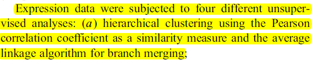

Analysis protocol in materials and methods section

```r
cancer_cor <- cor(cancer_norm, method="pearson") #create similarity matrix of correlations
head(cancer_cor)  #not shown on this page
```

### Executing the hierarchical clustering

How do we get from a similarity to a disimilarity matrix? By googling, of course! Search something like “similarity to distance matrix in R”. You will find the answer nestled inside the infinite wisdom of [R blogs](http://onertipaday.blogspot.com/2007/04/from-similarity-to-distance-matrix.html), which suggests using the `sim2dist()` method from the RFLPtools package. Just as before, we’ll need to install and load the package before we can use this function. Once we’ve used it, we can simiply plug in our distance matrix and our method (remember which one the methods said we should use?) into the `hclust()` method.

```r
install.packages("RFLPtools", repos="http://cran.rstudio.com/") #install package to convert similarity matrix to distance matrix
library("RFLPtools")
cancer_dist <- sim2dist(cancer_cor) #calculate distance matrix for clustering
cancer_clust <- hclust(cancer_dist, method="average") #hierarchical clustering
```

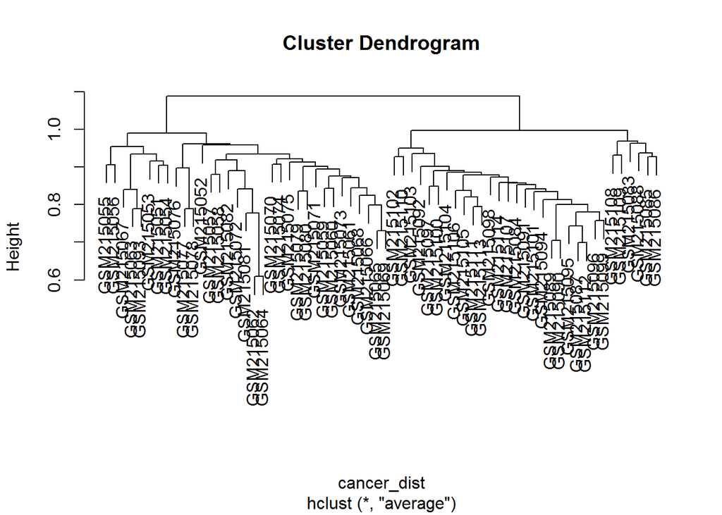

```r
plot(cancer_clust) #take a look at our clustering
```

### Plotting the heatmap

Almost there! Now, we just need to make a heatmap, which a quick search will reveal is done using the obviously named method `heatmap()`. From here on, I have dressed up the code to make the plot look similar to the one in the paper. Feel free to read more about dressing up [heatmap plots](https://stat.ethz.ch/R-manual/R-patched/library/stats/html/heatmap.html), but you needn’t understand exactly what the code is saying to get the idea. Just read the documentation if you are confused.

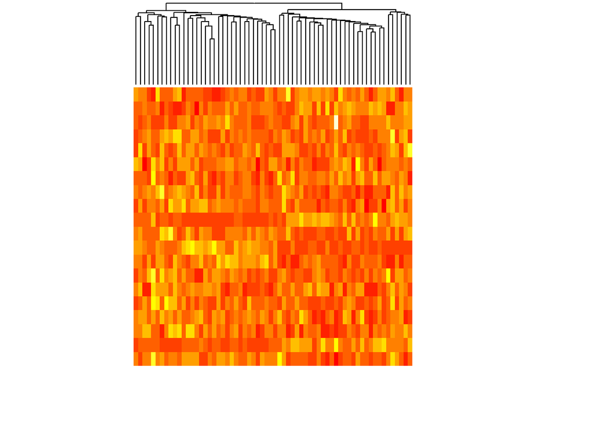

```r
#put the dendrogram on a heatmap
cancer_dend <- as.dendrogram(cancer_clust) #save the clusters to a format we can plot later
  #NA means I am hiding that item on the plot
heatmap(cancer_norm[1:20,], Rowv=NA, Colv=cancer_dend, labRow=NA, labCol=NA) #plot a heatmap
```

Change this color scheme from a divergent one to a sequential one using RColorBrewer.

```r
library(RColorBrewer)
display.brewer.all()
```

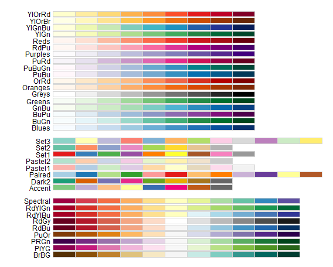

R Color Brewer

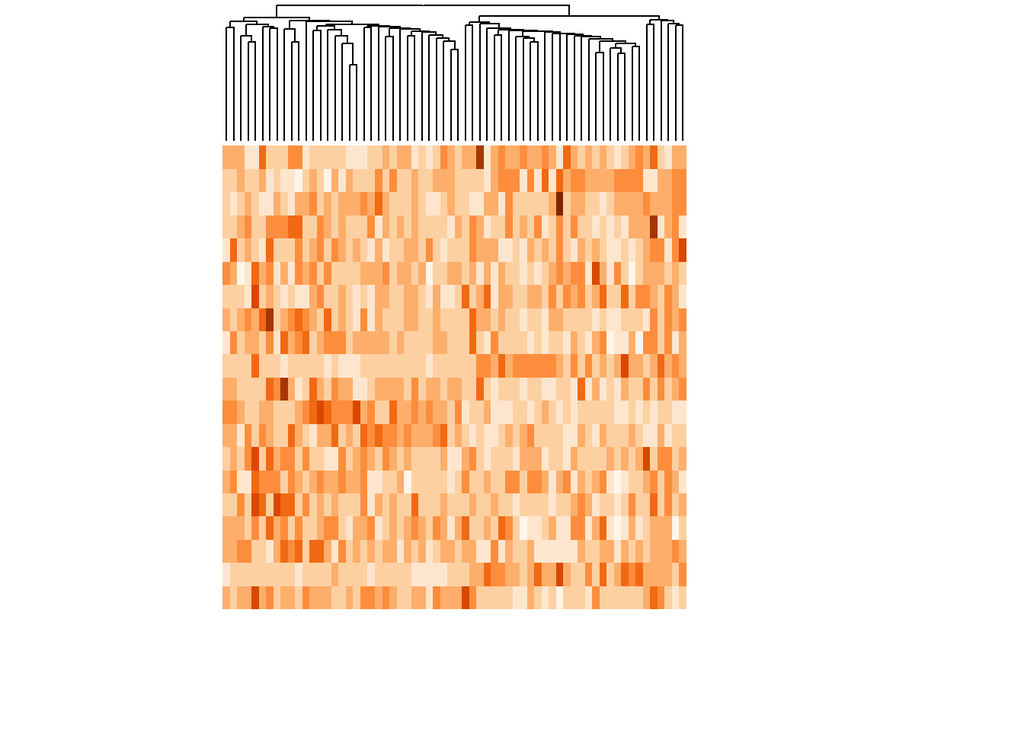

```r
heatmap(cancer_norm[1:20,], Rowv=NA, Colv=cancer_dend, labRow=NA, labCol=NA, col=brewer.pal(9,'Oranges')) #make the colormap better
```

Finally, let’s add colors and labels for the different sample types (adenoma and normal mucosa). Again, if you’d like a challenge, try reading the code, otherwise just enjoy the final product.

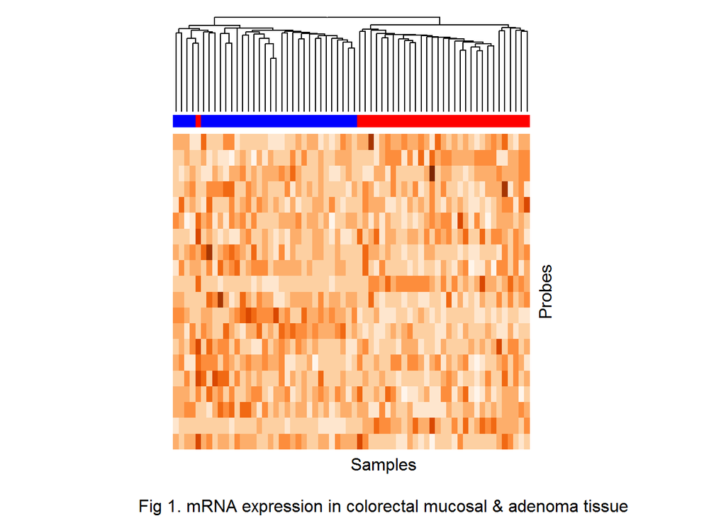

```r
#jazz it up
color.map <- function(disease_state) { if (disease_state=="adenoma") 'red' else 'blue' }
group_colors <- unlist(lapply(Columns(cancer)$disease.state, color.map)) #assign a color based on sample type
heatmap(cancer_norm[1:20,], Rowv=NA, Colv=cancer_dend, labRow=NA, labCol=NA, ylab="Probes", col=brewer.pal(9,'Oranges'), margins=c(5,2), main="", ColSideColors=group_colors)
mtext("Samples", side=1, line=2)
mtext("Fig 1. mRNA expression in colorectal mucosal & adenoma tissue", side=1, line=4) #improve margin spacing, add labels
```